# Strawberries

10/20/2020

## My Goal

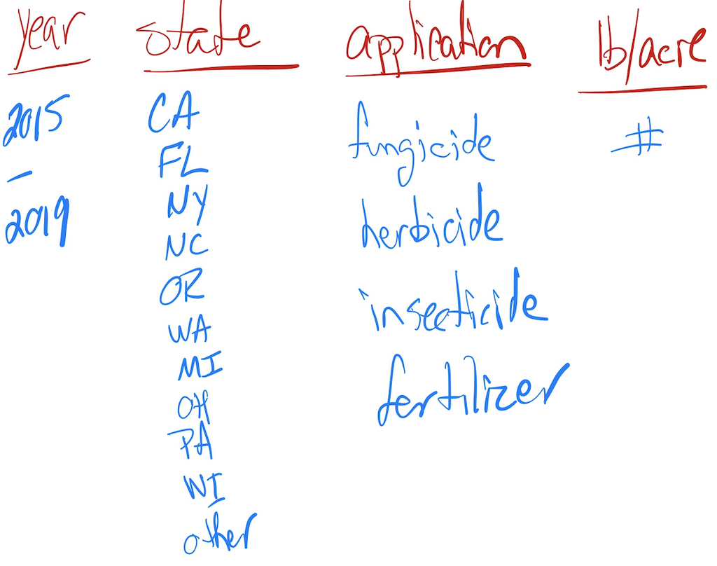

## My Workflow

1. Read and examine
2. Remove NA columns
3. Remove cols with no new info
4. Filter in ‘Strawberries’ & ‘Year’
5. Filter out unnecessary from “Domain” column
6. Filter in useful from “Data Items” column
7. Create an “Applications” column

## 1. Read and examine

These data were collected from the USDA database selector: https://quickstats.nass.usda.gov

The data were [stored online](https://quickstats.nass.usda.gov/results/D416E96E-3D5C-324C-9334-1D38DF88FFF1) and then downloaded to a CSV file.

The data has 21 columns.

```
##  [1] "Program"          "Year"             "Period"           "Week Ending"
##  [5] "Geo Level"        "State"            "State ANSI"       "Ag District"
##  [9] "Ag District Code" "County"           "County ANSI"      "Zip Code"
## [13] "Region"           "watershed_code"   "Watershed"        "Commodity"
## [17] "Data Item"        "Domain"           "Domain Category"  "Value"
## [21] "CV (%)"
```

## 2. Remove NA columns

I removed all the columns that only had NAs in them.

```r
NA_cols <- which(sapply(ag_data, function(x)all(is.na(x))))

ag_data %<>% select(-all_of(NA_cols))
```

I had these 12 columns.

```
##  [1] "Program"         "Year"            "Period"          "Geo Level"
##  [5] "State"           "State ANSI"      "watershed_code"  "Commodity"
##  [9] "Data Item"       "Domain"          "Domain Category" "Value"
```

## 3. Remove cols with no new info

“Program” and “Geo Level” have only 1 value.  
“State ANSI” adds no new information to “State”

```r
uni_cols <- sapply(ag_data,function(x) length(unique(x)))
ag_data %<>% subset(select=uni_cols>1)

ag_data %<>% select(-`State ANSI`)
```

This leaves 8 columns.

```
## [1] "Year"            "Period"          "State"           "Commodity"
## [5] "Data Item"       "Domain"          "Domain Category" "Value"
```

## 4. Filter in ‘Strawberries’ and ‘Year’

“PERIOD” col has 3 values:  
‘MARKETING YEAR’, ‘YEAR’, and ‘YEAR - AUG FORECAST’.  
I kept “PERIOD” = ‘YEAR’ for a consistent comparison.  
After filtering, I removed the “Period” and “Commodity” columns.

```r
straw <- ag_data %>% filter((Commodity=="STRAWBERRIES") &
                              (Period=="YEAR"))
straw %<>% select(-c(Period, Commodity))
```

This leaves 6 columns.

```
## [1] "Year"            "State"           "Data Item"       "Domain"
## [5] "Domain Category" "Value"
```

## 5. Filter out from “Domain” column

In the “Domain” column these are the unique entries:

```r
straw$'Domain' %>% unique
```

```
## [1] "TOTAL"                 "CHEMICAL, FUNGICIDE"   "CHEMICAL, HERBICIDE"
## [4] "CHEMICAL, INSECTICIDE" "CHEMICAL, OTHER"       "FERTILIZER"
```

I wanted to remove all the ‘TOTAL’ records.  
But first I needed to see what information was in those records.

```r
d_total <- filter(straw, Domain=="TOTAL")
d_total$`Data Item` %>% unique()
```

```
##  [1] "STRAWBERRIES - ACRES HARVESTED"
##  [2] "STRAWBERRIES - ACRES PLANTED"
##  [3] "STRAWBERRIES - PRODUCTION, MEASURED IN $"
##  [4] "STRAWBERRIES - PRODUCTION, MEASURED IN CWT"
##  [5] "STRAWBERRIES - YIELD, MEASURED IN CWT / ACRE"
##  [6] "STRAWBERRIES, FRESH MARKET - PRODUCTION, MEASURED IN $"
##  [7] "STRAWBERRIES, FRESH MARKET, UTILIZED - PRODUCTION, MEASURED IN CWT"
##  [8] "STRAWBERRIES, NOT SOLD - PRODUCTION, MEASURED IN CWT"
##  [9] "STRAWBERRIES, PROCESSING - PRODUCTION, MEASURED IN $"
## [10] "STRAWBERRIES, PROCESSING, UTILIZED - PRODUCTION, MEASURED IN CWT"
## [11] "STRAWBERRIES, UTILIZED - PRODUCTION, MEASURED IN CWT"
## [12] "STRAWBERRIES, PROCESSING, UTILIZED - PRODUCTION, MEASURED IN TONS"
## [13] "STRAWBERRIES, PROCESSING - PRODUCTION, MEASURED IN CWT"
## [14] "STRAWBERRIES, FRESH MARKET - PRODUCTION, MEASURED IN CWT"
```

[output not shown]

None of these entries referred to chemical applications. So I was comfortable removing those records.

```r
straw <- filter(straw, Domain!="TOTAL")
```

This brought the data.frame down from 3,220 rows to 2,862 rows.

## 6. Filter in from “Data Items” column

In this column there were 5 unique entries

```r
straw$'Data Item' %>% unique
```

```
## [1] "STRAWBERRIES, BEARING - APPLICATIONS, MEASURED IN LB"
## [2] "STRAWBERRIES, BEARING - APPLICATIONS, MEASURED IN LB / ACRE / APPLICATION, AVG"
## [3] "STRAWBERRIES, BEARING - APPLICATIONS, MEASURED IN LB / ACRE / YEAR, AVG"
## [4] "STRAWBERRIES, BEARING - APPLICATIONS, MEASURED IN NUMBER, AVG"
## [5] "STRAWBERRIES, BEARING - TREATED, MEASURED IN PCT OF AREA BEARING, AVG"
```

I made a table to see which of these categories had the most information for me to use.

| Var1 | Freq |
| --- | --- |
| STRAWBERRIES, BEARING - APPLICATIONS, MEASURED IN LB | 591 |
| STRAWBERRIES, BEARING - APPLICATIONS, MEASURED IN LB / ACRE / APPLICATION, AVG | 560 |
| STRAWBERRIES, BEARING - APPLICATIONS, MEASURED IN LB / ACRE / YEAR, AVG | 560 |
| STRAWBERRIES, BEARING - APPLICATIONS, MEASURED IN NUMBER, AVG | 560 |
| STRAWBERRIES, BEARING - TREATED, MEASURED IN PCT OF AREA BEARING, AVG | 591 |

Since the frequencies were almost identical, I used:  
“LB/ACRE/YEAR, AVG.”

I then filtered in these rows and deleted the “Data Item” column, and renamed the “Value” column to be “Avg lb/acre/yr.”

```r
target<-"STRAWBERRIES, BEARING - APPLICATIONS, MEASURED IN LB / ACRE / YEAR, AVG"
straw %<>% filter(straw$'Data Item'==target) %<>%
  select(-('Data Item'))
colnames(straw)[5] <-"Avg lb/acre/yr"
```

The data.frame so far:

| Year | State | Domain | Domain Category | Avg lb/acre/yr |
| --- | --- | --- | --- | --- |
| 2019 | CALIFORNIA | CHEMICAL, FUNGICIDE | CHEMICAL, FUNGICIDE: (AZOXYSTROBIN = 128810) | 0.447 |
| 2019 | CALIFORNIA | CHEMICAL, FUNGICIDE | CHEMICAL, FUNGICIDE: (BACILLUS AMYLOLIQUEFACIENS MBI 600 = 129082) | (NA) |
| 2019 | CALIFORNIA | CHEMICAL, FUNGICIDE | CHEMICAL, FUNGICIDE: (BACILLUS AMYLOLIQUEFACIENS STRAIN D747 = 16482) | (NA) |
| 2019 | CALIFORNIA | CHEMICAL, FUNGICIDE | CHEMICAL, FUNGICIDE: (BACILLUS PUMILUS = 6485) | (NA) |

## 7. Create an “Application” column.

I separated the “Domain” column and kept just the back end of each of the entries.  
I relabeled this column “Application.”

```r
straw %<>% separate(Domain, c("D_left", "D_right"), sep = ", ") %>%
  select(-('D_left'))
colnames(straw)[3] <-"Application"
```

This gave the following unique entries in “Application”:

```
## [1] "FUNGICIDE"   "HERBICIDE"   "INSECTICIDE" "OTHER"       NA
```

Then I needed to see if all of the NAs in the “Application” column were when a ‘FERTILIZER’ was used.  
To do this I wrote a loop that checked each row to see if, when the entry in “Application” was = NA, the “Domain Category” contained ‘FERTILIZER.’

```r
n<-length(straw$Application)
x<-0
for (i in (1:n)) {
  one <- straw$Application[i]=="NA"
  two <- is.na(straw$Application[i])
  three <-  (str_detect(straw$`Domain Category`[i], "FERTILIZER"))
  if (one | two & three) {
    x <- x+1
  }
}
print(x)
```

```
## [1] 15
```

```r
straw %<>% select(-("Domain Category"))
straw$Application <- factor(straw$Application)
#revalue(straw$Application, c("FUNGICIDE"="Fungicide", "HERBICIDE"="Herbicide",
#                             "INSECTICIDE"="Insecticide", "OTHER"="Fertilizer"))
#This was my first attempt, but I couldn't figure out how to get it to NOT print out
#all 560 straw$Application entries when it ran.  So I did the following:

levels(straw$Application)[levels(straw$Application)=="OTHER"]<-"FERTILIZER"
```

Finally, I filtered out records where “Application” contained ‘OTHER,’  
and where “Avg lb/acre/yr” contained (NA) or (D).

```r
straw %<>% filter(Application != "OTHER")
straw %<>% filter(straw$"Avg lb/acre/yr" != "(D)")
straw %<>% filter(straw$"Avg lb/acre/yr" != "(NA)")
```

This got me down to 225 records.

## MY FINAL PRODUCT

(n=225)

| Year | State | Application | Avg lb/acre/yr |
| --- | --- | --- | --- |
| 2019 | CALIFORNIA | FUNGICIDE | 0.447 |
| 2019 | CALIFORNIA | FUNGICIDE | 0.54 |
| 2019 | CALIFORNIA | FUNGICIDE | 0.051 |
| 2019 | CALIFORNIA | FUNGICIDE | 0.508 |
| 2019 | CALIFORNIA | FUNGICIDE | 10.456 |
| 2019 | CALIFORNIA | FUNGICIDE | 0.034 |
| 2019 | CALIFORNIA | FUNGICIDE | 0.765 |
| 2019 | CALIFORNIA | FUNGICIDE | 0.25 |